# An Analysis on Differing Average Patient Payments Across Hospitals in the United States

Edward Chang

November 1, 2019

## 1 : Data Entry

```r
# Code for 1 : Data Entry

# Read data in
alldata = read.csv("combinedData.csv")
# Remove unwanted observations
data = alldata[alldata$DRG.Definition %in% c("192 - CHRONIC OBSTRUCTIVE PULMONARY DISEASE W/O CC/MCC",
    "293 - HEART FAILURE & SHOCK W/O CC/MCC", "536 - FRACTURES OF HIP & PELVIS W/O MCC",
    "638 - DIABETES W CC"), ]
# Make Urban a factor
data$Urban = factor(data$Urban, levels = 0:5, labels = c("UR Mix", "R Regions",
    "RU Clusters", "U Clusters", "U Combo", "U Areas"))
# Calculate how much a patient pays
data$PatientPays = data$Average.Total.Payments - data$Average.Medicare.Payments
# Calculate the percentage of what a patient pays
data$PctPatientPays = data$PatientPays/data$Average.Total.Payments * 100
# Create a new factor vector by crossing Urban and regions
data$urbanByRegions = data$Urban:data$regions
# Drop unused levels
data = droplevels.data.frame(data)
# Print out summary
print(summary(data))
```

```
##  Provider.State                                                DRG.Definition
##  CA     : 596   192 - CHRONIC OBSTRUCTIVE PULMONARY DISEASE W/O CC/MCC:2593
##  TX     : 592   293 - HEART FAILURE & SHOCK W/O CC/MCC                :2443
##  FL     : 519   536 - FRACTURES OF HIP & PELVIS W/O MCC               :1103
##  NY     : 459   638 - DIABETES W CC                                   :1762
##  PA     : 399
##  IL     : 389
##  (Other):4947
##   Provider.Id                      Provider.Name       Provider.City
##  Min.   : 10001   GOOD SAMARITAN HOSPITAL :  29   CHICAGO     :  81
##  1st Qu.:110186   MERCY MEDICAL CENTER    :  20   BALTIMORE   :  42
##  Median :250069   ST JOSEPH HOSPITAL      :  20   BROOKLYN    :  41
##  Mean   :257006   ST JOSEPH MEDICAL CENTER:  20   HOUSTON     :  41
##  3rd Qu.:390016   MERCY HOSPITAL          :  19   PHILADELPHIA:  40
##  Max.   :670071   ST FRANCIS HOSPITAL     :  15   SPRINGFIELD :  37
##                   (Other)                 :7778   (Other)     :7619
##  Total.Discharges Average.Covered.Charges Average.Total.Payments
##  Min.   : 11.00   Min.   :  3134          Min.   : 3144
##  1st Qu.: 17.00   1st Qu.: 11352          1st Qu.: 4212
##  Median : 25.00   Median : 15544          Median : 4711
##  Mean   : 33.47   Mean   : 18368          Mean   : 5072
##  3rd Qu.: 41.00   3rd Qu.: 22070          3rd Qu.: 5532
##  Max.   :326.00   Max.   :130690          Max.   :19512
##
##  Average.Medicare.Payments Provider.Zip.Code      regions
##  Min.   : 2182             Min.   : 1040     midwest  :1842
##  1st Qu.: 3255             1st Qu.:27565     northeast:1469
##  Median : 3723             Median :44112     south    :3357
##  Mean   : 4093             Mean   :47812     west     :1233
##  3rd Qu.: 4517             3rd Qu.:72342
##  Max.   :18613             Max.   :99701
##
##          Urban       PatientPays      PctPatientPays             urbanByRegions
##  UR Mix     :2948   Min.   :  261.2   Min.   : 3.898   UR Mix:south     :1239
##  R Regions  : 104   1st Qu.:  770.2   1st Qu.:15.297   RU Clusters:south:1010
##  RU Clusters:1827   Median :  898.4   Median :19.230   U Areas:south    : 784
##  U Clusters :   6   Mean   :  979.3   Mean   :19.949   UR Mix:midwest   : 663
##  U Areas    :2520   3rd Qu.: 1059.3   3rd Qu.:23.569   U Areas:northeast: 625
##  NA's       : 496   Max.   :10676.8   Max.   :74.215   (Other)          :3084
##                                                        NA's             : 496
```

## 2 : Basic Summaries

```r
# Code for 2 : Basic Summaries

# Print out basic summaries for PatientPays and PctPatientPays
for (diag in levels(data$DRG.Definition)) {
    with(data[data$DRG.Definition == diag, ], {
        # label the type of diagnosis
        cat(paste(diag, "\n"))
        print("PatientPays Summary")
        print(summary(PatientPays))
        print("PctPatientPays Summary")
        print(summary(PctPatientPays))
        # make a dashed line for visibility
        cat("______________________________\n")
    })
}
```

```
## 192 - CHRONIC OBSTRUCTIVE PULMONARY DISEASE W/O CC/MCC
## [1] "PatientPays Summary"
##    Min. 1st Qu.  Median    Mean 3rd Qu.    Max.
##   372.0   847.2   963.4  1064.4  1162.8  5701.0
## [1] "PctPatientPays Summary"
##    Min. 1st Qu.  Median    Mean 3rd Qu.    Max.
##   5.606  17.484  21.196  21.952  25.625  64.149
## ______________________________
## 293 - HEART FAILURE & SHOCK W/O CC/MCC
## [1] "PatientPays Summary"
##    Min. 1st Qu.  Median    Mean 3rd Qu.    Max.
##   261.2   694.3   793.8   854.1   926.8  7009.3
## [1] "PctPatientPays Summary"
##    Min. 1st Qu.  Median    Mean 3rd Qu.    Max.
##   3.898  14.974  18.159  18.693  21.518  66.968
## ______________________________
## 536 - FRACTURES OF HIP & PELVIS W/O MCC
## [1] "PatientPays Summary"
##    Min. 1st Qu.  Median    Mean 3rd Qu.    Max.
##   508.7   890.3   965.7  1027.3  1057.6  3693.7
## [1] "PctPatientPays Summary"
##    Min. 1st Qu.  Median    Mean 3rd Qu.    Max.
##   7.703  18.345  21.926  22.057  24.736  53.625
## ______________________________
## 638 - DIABETES W CC
## [1] "PatientPays Summary"
##    Min. 1st Qu.  Median    Mean 3rd Qu.    Max.
##   268.0   724.3   859.6   997.4  1079.4 10676.8
## [1] "PctPatientPays Summary"
##    Min. 1st Qu.  Median    Mean 3rd Qu.    Max.
##   4.187  12.284  15.941  17.421  20.418  74.215
## ______________________________
```

### Comments on summaries:

Excluding the max, between all subsets of the data, the summary statistics are all very similar (varying around $\pm 200$ in `PatientPays` and $\pm 5$% in `PctPatientPays`. Since the maximums of the `PatientPays` variable have such a big value compared to the majority of the data it would be wise to use a log transformation if trying to visualize the variable in subsequent parts. We can consider the large max values of `PctPatientPays` to be negliable (when trying to visualize it) due to its nature as a percent and usage of a small range of values.

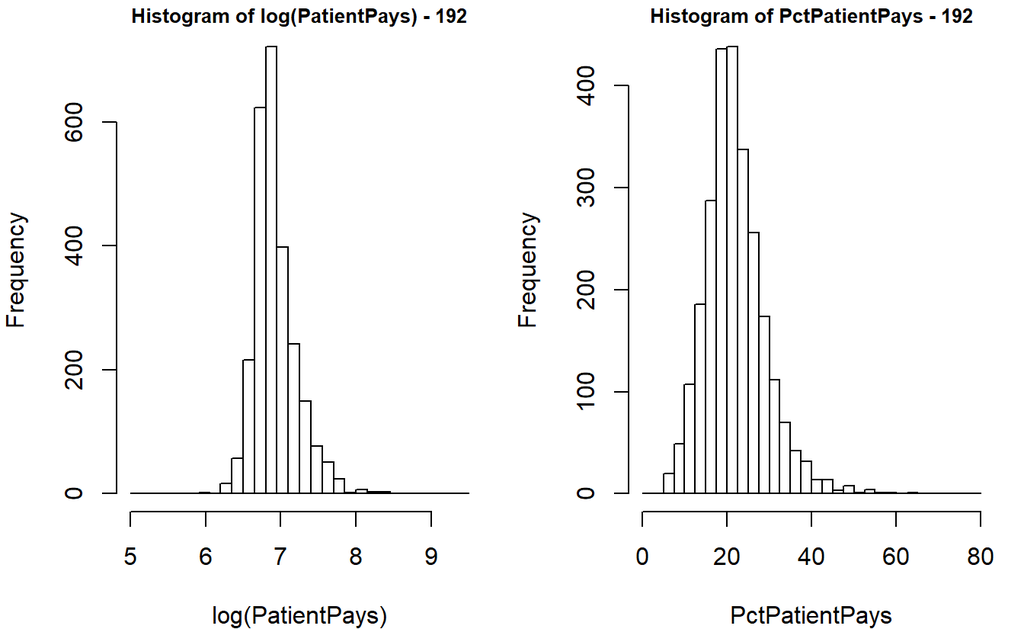

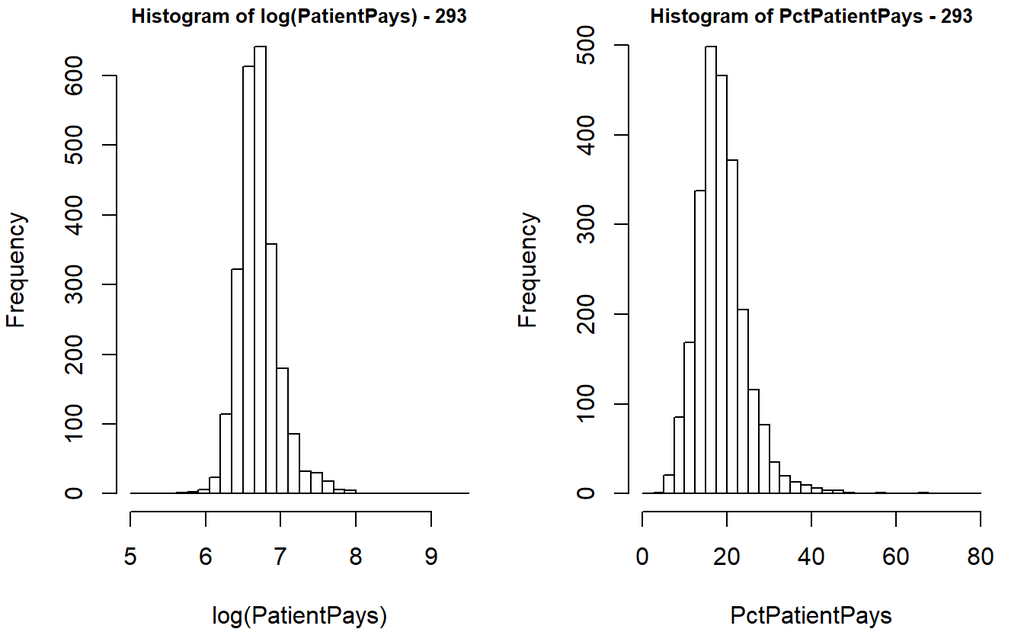

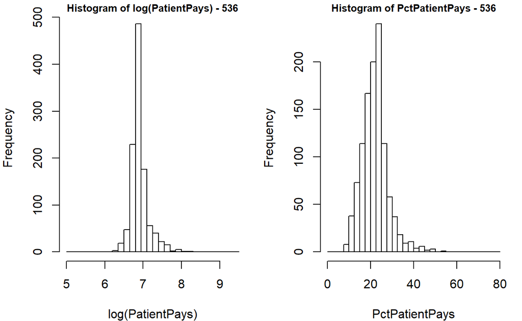

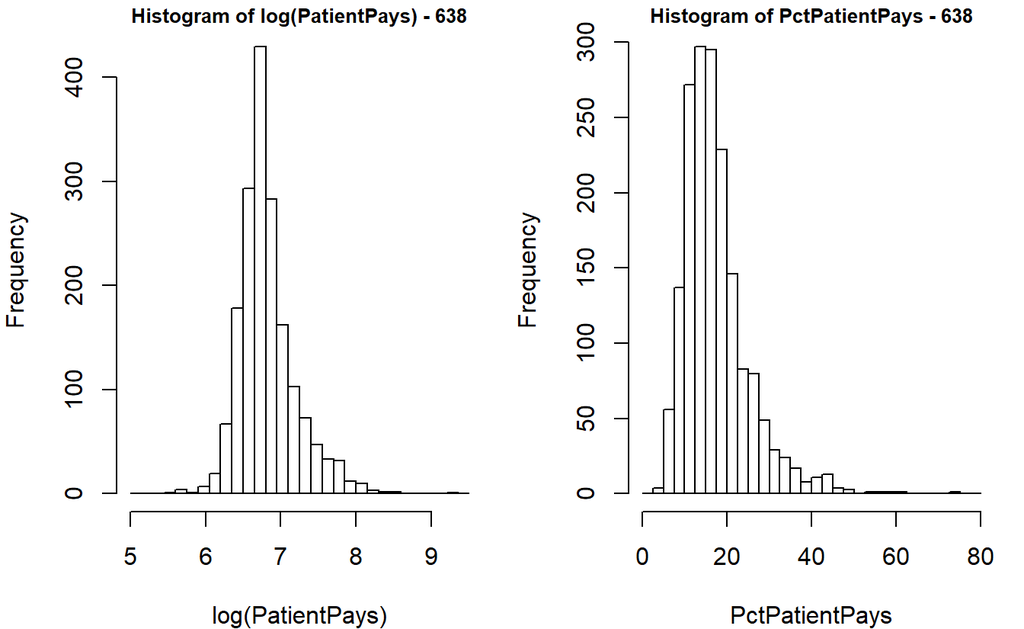

```r
# Code for 2 : Basic Summaries (Cont.)

# Code for basic histograms of PatientPays and PctPatientPays for each
# diagnosis group
for (diag in levels(data$DRG.Definition)) with(data[data$DRG.Definition ==
    diag, ], {
    par(mfrow = c(1, 2), mar = c(4, 4, 1, 1))
    # transform PatientPays with log() because all the observations on the
    # left are cluttered
    hist(log(PatientPays), breaks = seq(5, 9.5, 0.15), main = paste("Histogram of log(PatientPays) -",
        substr(diag, 1, 3)), cex.main = 0.8)
    hist(PctPatientPays, breaks = seq(0, 80, 2.5), main = paste("Histogram of PctPatientPays -",
        substr(diag, 1, 3)), cex.main = 0.8)
})
```

### Comments on histograms:

As the histograms show, the distributions of the variables are fairly similar between diagnoses when looking at the variables in whole, and the range of the data is mainly what causes variation between the histograms. Since a `log` transformation was used to transform the `PatientPays` variable, the distribution of it also ends up clearer and requires less bins to show the relative shape of the distribution.

```r
# Code for 2 : Basic Summaries (Cont.)

# Code for contingency tables of Urban and regions for each diagnosis
for (diag in levels(data$DRG.Definition)) {
    with(data[data$DRG.Definition == diag, ], {
        cat(paste(diag, "\n"))  # give classification to the summaries
        print(table(Urban, regions))
        cat("______________________________\n")  # make a line for easy differentian between groups
    })
}
```

```
## 192 - CHRONIC OBSTRUCTIVE PULMONARY DISEASE W/O CC/MCC
##              regions
## Urban         midwest northeast south west
##   UR Mix          208       159   387  155
##   R Regions         5         5    40    1
##   RU Clusters     197        79   431   72
##   U Clusters        0         1     1    0
##   U Areas         172       174   222  141
## ______________________________
## 293 - HEART FAILURE & SHOCK W/O CC/MCC
##              regions
## Urban         midwest northeast south west
##   UR Mix          203       163   365  159
##   R Regions         7         5    26    1
##   RU Clusters     178        72   352   57
##   U Clusters        0         1     1    0
##   U Areas         173       176   222  142
## ______________________________
## 536 - FRACTURES OF HIP & PELVIS W/O MCC
##              regions
## Urban         midwest northeast south west
##   UR Mix           97        98   184   80
##   R Regions         0         2     1    0
##   RU Clusters      33        12    54   12
##   U Clusters        0         0     1    0
##   U Areas         110       109   141   82
## ______________________________
## 638 - DIABETES W CC
##              regions
## Urban         midwest northeast south west
##   UR Mix          155       115   303  117
##   R Regions         1         1     8    1
##   RU Clusters      56        36   173   13
##   U Clusters        0         0     1    0
##   U Areas         157       166   199  134
## ______________________________
```

### Comments on contingency tables:

In these contingency tables, the counts show that there are few observations for which `Urban` has the values of 1, 3, or 4, with 4 having 0 observations (where 1 is `R Regions`, 3 is `U Clusters`, 4 is `U Combo`). In contrast to the other `Urban` levels, these levels are few in number and might not provide much to the overall data or provide enough to generate an accurate null distribution in the following hypothesis tests. The other groups are fairly large enough for hypothesis tesing.

## 3 : Exploration of Distributions in Groups

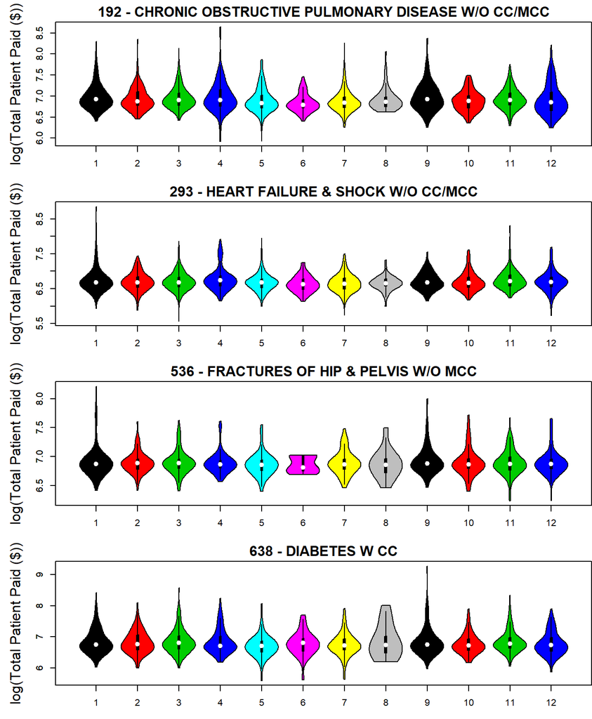

```r
# Code for 3 : Exploration of Distributions in Groups

# Subset data to exclude values of Urban corresponding to 1, 3, or 4
# and also drop all unneeded levels & unused columns
exclude = droplevels.data.frame(data[!(data$Urban %in% c("R Regions", "U Clusters",
    "U Combo", NA)), ])[, names(data) %in% c("urbanByRegions", "DRG.Definition",
    "PatientPays", "PctPatientPays")]
require(vioplot)  # Load in vioplot package
source("http://www.stat.berkeley.edu/~epurdom/RcodeForClasses/myvioplot.R")  # Load in Professor Prudom's function
with(exclude, {
    par(mfrow = c(4, 1), mar = c(3, 5, 2, 0))
    # violin plots for `PatientPays` for each diagnosis by `urbanByRegions
    for (diag in levels(DRG.Definition)) {
        vioplot2(log(PatientPays[DRG.Definition == diag]), as.numeric(urbanByRegions[DRG.Definition ==
            diag]), col = palette(), main = diag, ylab = "log(Total Patient Paid ($))",
            cex.lab = 1.5, cex.main = 1.5)
        axis(side = 1, labels = F)  # remove x-axis labels to make a cleaner output
    }
    # create a note for clarification of the x-axis labels
    cat(paste("Note: With the numbers 1-12 indicating the levels in `urbanByRegions`:",
        paste(levels(exclude$urbanByRegions), collapse = ", "), "\n"))
})
```

Note: With the numbers 1-12 indicating the levels in `urbanByRegions`: UR Mix:midwest, UR Mix:northeast, UR Mix:south, UR Mix:west, RU Clusters:midwest, RU Clusters:northeast, RU Clusters:south, RU Clusters:west, U Areas:midwest, U Areas:northeast, U Areas:south, U Areas:west

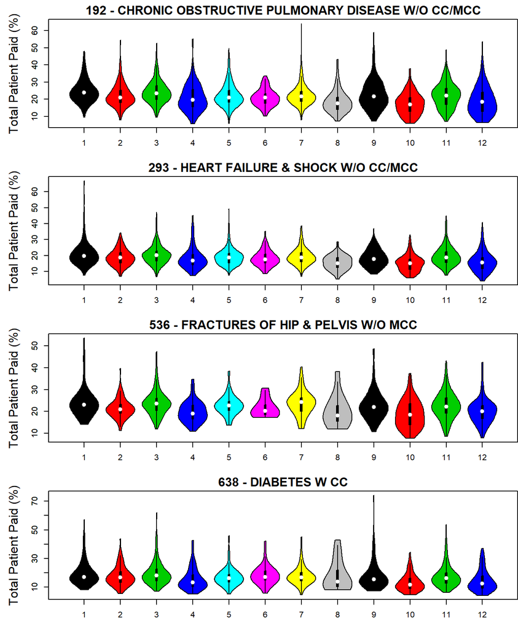

```r
with(exclude, {
    par(mfrow = c(4, 1), mar = c(3, 5, 2, 0))
    # violin plots for `PctPatientPays` for each diagnosis by
    # `urbanByRegions
    for (diag in levels(DRG.Definition)) {
        vioplot2(PctPatientPays[DRG.Definition == diag], as.numeric(urbanByRegions[DRG.Definition ==
            diag]), col = palette(), main = diag, ylab = "Total Patient Paid (%)",
            cex.lab = 1.5, cex.main = 1.5)
        axis(side = 1, labels = F)
    }
    cat(paste("Note: With the numbers 1-12 indicating the levels in `urbanByRegions`:",
        paste(levels(exclude$urbanByRegions), collapse = ", "), "\n"))
})
```

Note: With the numbers 1-12 indicating the levels in `urbanByRegions`: UR Mix:midwest, UR Mix:northeast, UR Mix:south, UR Mix:west, RU Clusters:midwest, RU Clusters:northeast, RU Clusters:south, RU Clusters:west, U Areas:midwest, U Areas:northeast, U Areas:south, U Areas:west

### Comments on 3:

The violin plots of each variable are very similar to each other in the shape of the distribution and due to the use of a log transformation in the `PatientPays` variable, there is considerable clumping of the observations at the center line of each of the distributions. The log transformation also makes the distributions between the two variables extremely similar since the long tails caused by extreme values are brought closer to the bulk of the data. It’s also notable that levels `6` (`RU Clusters:northeast`), `8` (`RU Clusters:west`) across all diagnoses and the two variables may be lacking a large enough number of observations to create a nice full violin plot due to their truncated nature without a proper tail.

## 4 : Perform inference to evaluate the difference between the groups

```r
# Code for 4 : Perform inference to evaluate the difference between the groups

# Set up functions/objects for use in later code chunks

# Proceding with permutation method to simulate for p-values in pairwise testing:

# function to retrive the t-statistic from 2 groups
t.statistic = function(x, y) {
  return(t.test(x, y)$statistic)
}

# professor's function from hw 2 (does a permutation test with a size repetitions sample)
permutation.test <- function(group1,group2, FUN, repetitions){
  makePermutedStats<-function(){
      sampled <- sample(1:length(c(group1,group2)), size=length(group1),replace=FALSE)
      return(FUN(c(group1,group2)[sampled], c(group1,group2)[-sampled]))
  }
  stat.obs <- FUN(group1,  group2)
  stat.permute <-replicate(repetitions,makePermutedStats())
  p.value <- sum(stat.permute >= stat.obs) / repetitions
  return(list(p.value=p.value,observedStat=stat.obs,permutedStats=stat.permute))
}
# function to call permutation.test with a pair (x), dataframe (df), and variable of interest (pay)
permtestFun<-function(x, df, pay){
    group1<-df[,pay][df[,'urbanByRegions'] == x[1]]
    group2<-df[,pay][df[,'urbanByRegions'] == x[2]]
    permutation.test(group1,group2,t.statistic, 1000)
}
# retrive values from a list
get_vals = function(list, index = 1) {
  sapply(list,FUN='[[', i = index)
}
# get test statistics from permulation tests (Create list of all p.values for each diagnosis' pairwise testing in a list)
get_stats = function(pct = F) {
  if (pct) pay = 'PctPatientPays' else pay = 'PatientPays'
  lapply(lapply(dfs, FUN = function(df) apply(X = pairs, MARGIN = 2, FUN = permtestFun, df = df, pay = pay)), FUN = get_vals)
}


# load in iterators package for eash of title change
require(iterators)
# create function to plot p-values together (with a transformation using the log of the values)
plot.p = function(list, correct = F, ylab = 'log(p.value)') {
  par(mfrow = c(2, 2), mar = c(2,5,2,1))
  # create an iterable for ease of title plot change
  titles = iter(c('192', '293', '536', '638'))
  # for loop to iterate through every diagnosis group
  for (group in list) {
    # if bonferroni corrections are specified to use, adjust the p values accordingly
    if (correct == F) p.values = group
    else {
      p.values = pmin(group * length(group), 1)
      ylab = paste('log(p.value *', length(group), ')')
    }
    p.values = log(p.values)
    plot(seq(length(p.values)), p.values, col = sapply(p.values, FUN = function(x) {if (x < log(.05)) 'red' else 'black'}), # make p-values that reject red
         xaxt = 'n', xlab = '', ylab = ylab , main = nextElem(titles))
    # draw the alpha value line
    abline(a = log(.05), b = 0, lty =2, lwd =2)
  }
}


# Code for making 95% Confidence Intervals using the bootstrap method
bootstrap.ci = function(x, df, pay, correct = F) {
  group1 = df[,pay][df[,'urbanByRegions'] == x[1]]
  group2 = df[,pay][df[,'urbanByRegions'] == x[2]]
  obs = t.statistic(x = group1, y = group2)
  # function to simulate one bootstrap
  once = function(){
    group1 = sample(group1, length(group1), repl = T)
    group2 = sample(group2, length(group2), repl = T)
    return(t.statistic(x = group1, y = group2))
  }
  #simulate 1000 bootraps
  bootstrap.stats = replicate(1000, once())
  # account for whether or not I want a bonferonni correction
  if(correct) level = .05/66 else level = .05
  confidence.interval = quantile(bootstrap.stats, probs = c(level/2, 1 - level/2))
  return(c(confidence.interval[1], obs, confidence.interval[2]))
}

# load in gplots package
require(gplots)
plot.ci = function(list, correct = F){
  # Create iterable for ease of title change
  titles = iter(c('192', '293', '536', '638'))
  # plot CI's for each diagnosis
  for (m in list){
    plotCI(m[2,], ui = m[3,], li = m[1,], main = paste(nextElem(titles), 'CIs'), col = apply(m, 2, FUN = function(x) {if (0 > x[1] & 0 <x[3]) 'black' else 'red'}), pch = 19, xaxt = "n", xlim = c(0, 67))
    abline(h = 0, lty = 2) # make line at y=0
  }
}

# separate dataframe into a list of four separate data frames for each diagnosis
dfs = lapply(X = lapply(X = levels(exclude$DRG.Definition), FUN = function(x) exclude[exclude$DRG.Definition == x,]), droplevels.data.frame)
# create matrix of all possible pairs in urbanByRegions
pairs = combn(x =levels(exclude$urbanByRegions), m = 2)
```

## Inference for `PatientPays`

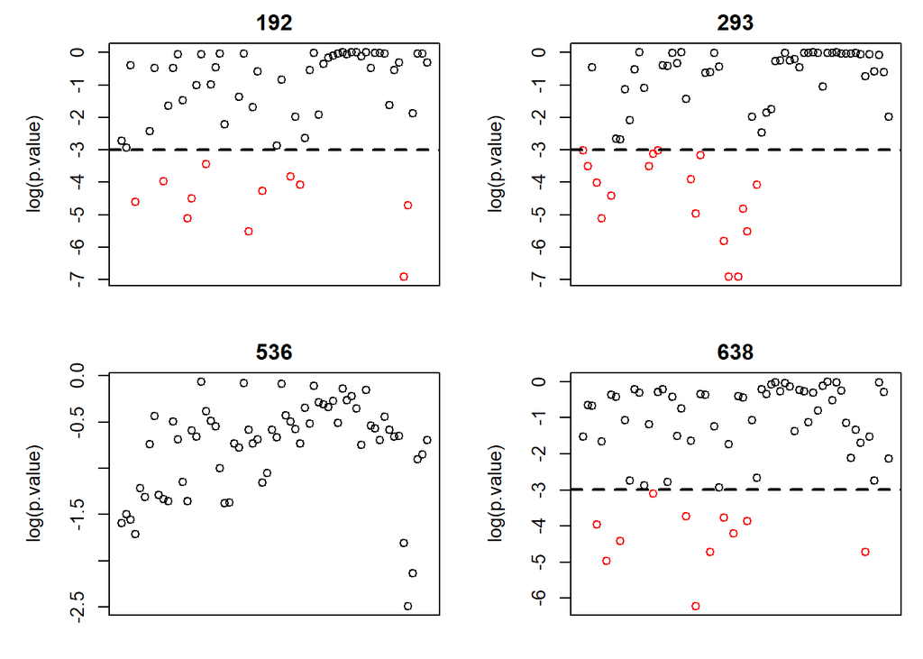

```r
# Code for 4 : Perform inference to evaluate the difference between the
# groups (cont.)

# Apply the previously defined functions and objects to perform
# hypothesis testing

# For the variable PatientPays : Create list of all p.values for each
# diagnosis' pairwise testing in a list
stats = get_stats()
# plot w/o bonferonni corrections
plot.p(stats)
```

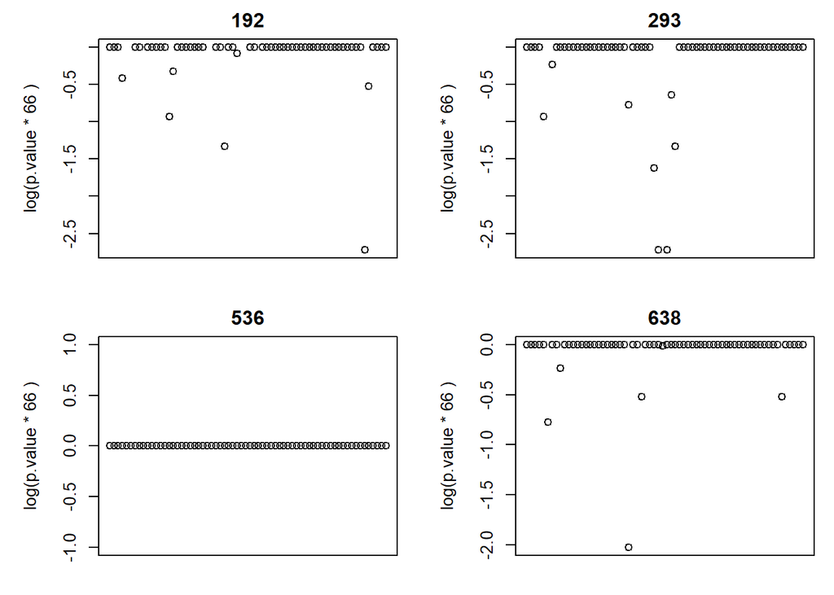

```r
# plot w/bonferonni corrections
plot.p(stats, correct = T)
```

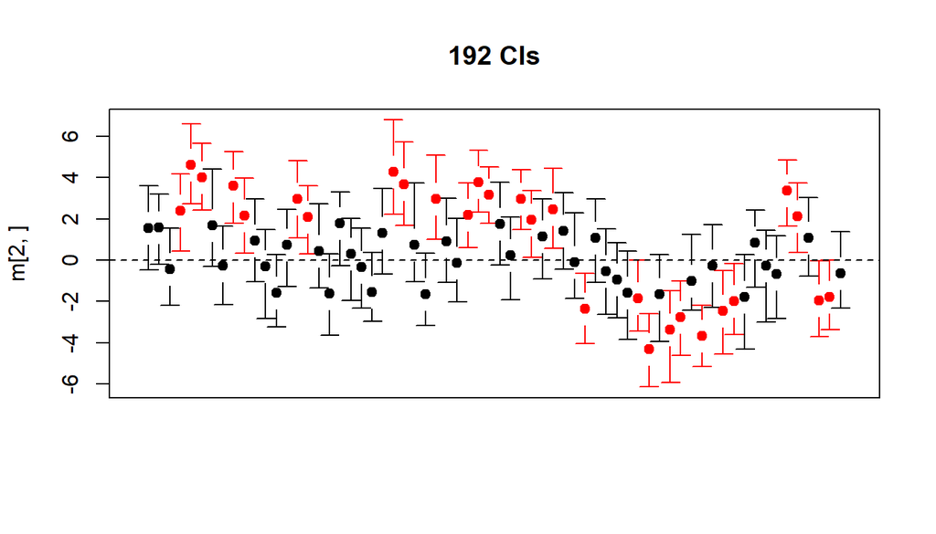

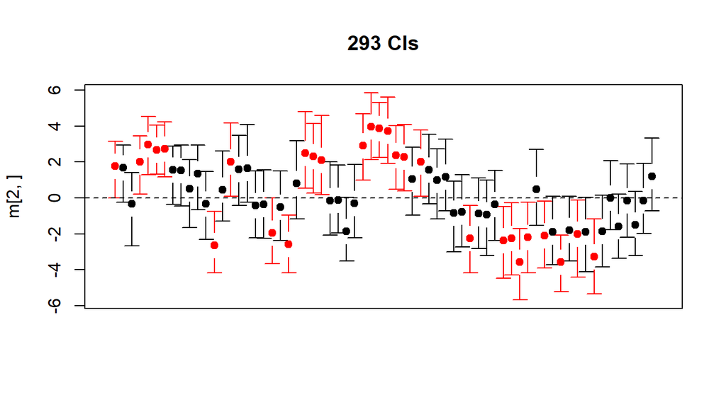

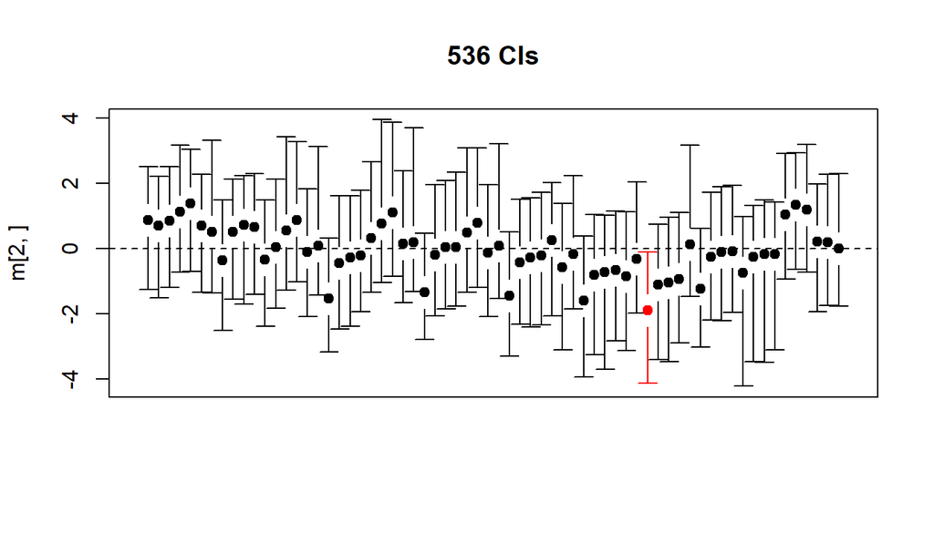

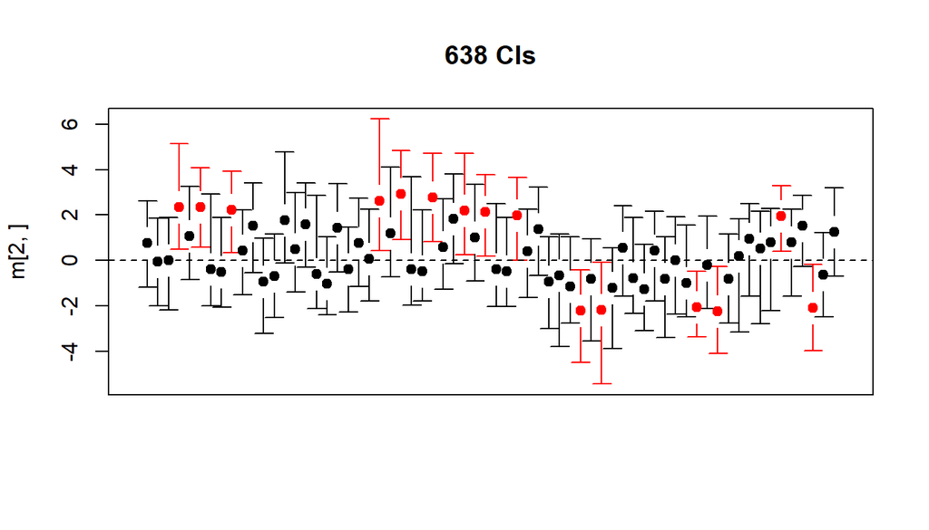

```r
# create bootstrap sample
boot = lapply(X = dfs, function(df) {
    apply(X = pairs, MARGIN = 2, FUN = bootstrap.ci, df = df, pay = "PatientPays")
})
boot.cor = lapply(X = dfs, function(df) {
    apply(X = pairs, MARGIN = 2, FUN = bootstrap.ci, df = df, pay = "PatientPays",
        correct = T)
})

# Now plot
plot.ci(boot)
```

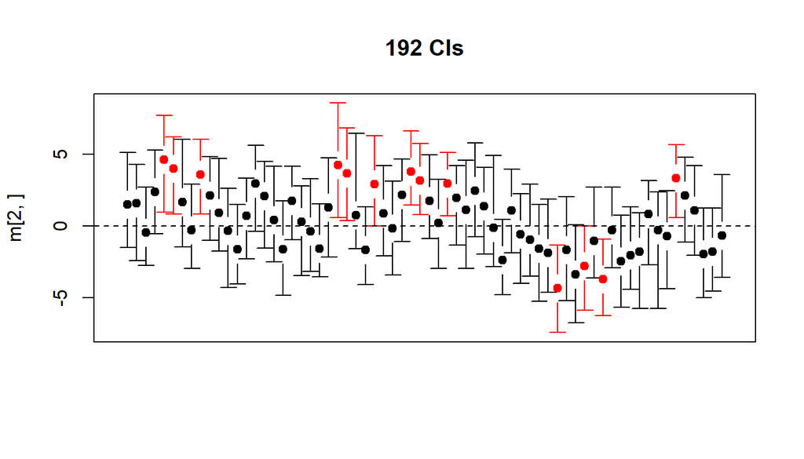

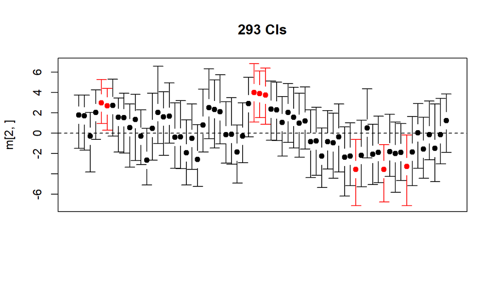

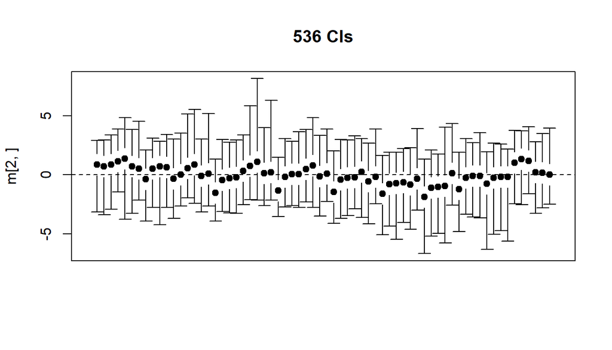

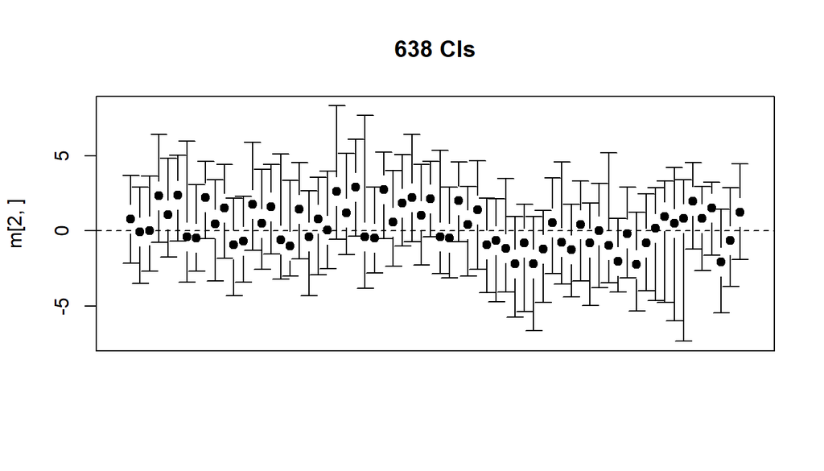

```r
plot.ci(boot.cor)
```

## Inference for `PctPatientPays`

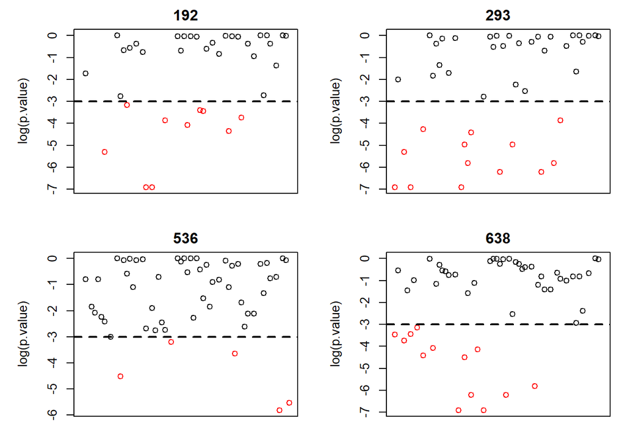

```r
# Code for 4 : Perform inference to evaluate the difference between the
# groups (cont.)

# now do the same thing as the previous code but for `PctPatientPays`
stats.per = get_stats(pct = T)
plot.p(stats.per)
```

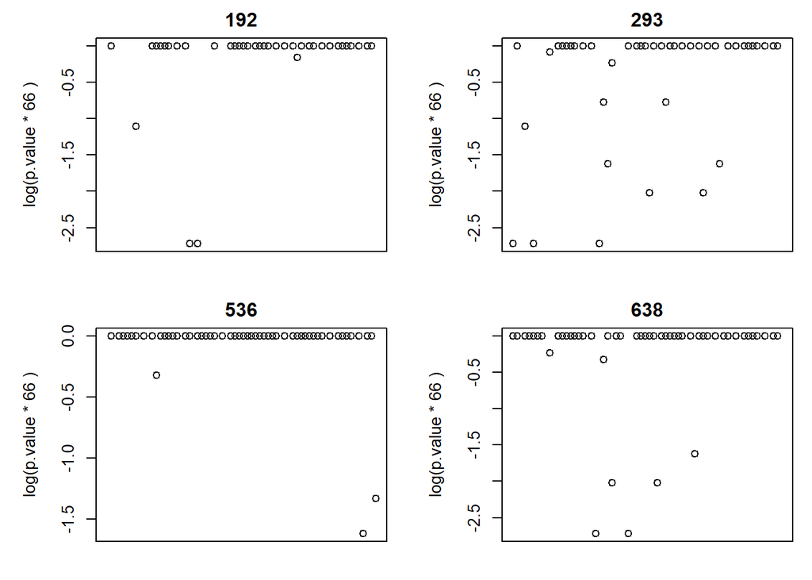

```r
plot.p(stats.per, correct = T)
```

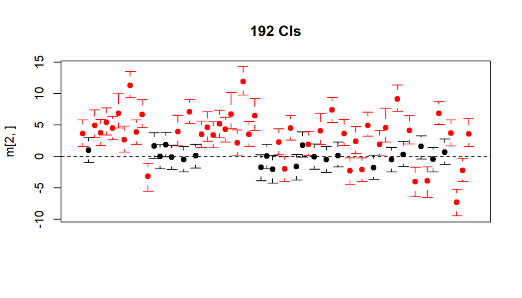

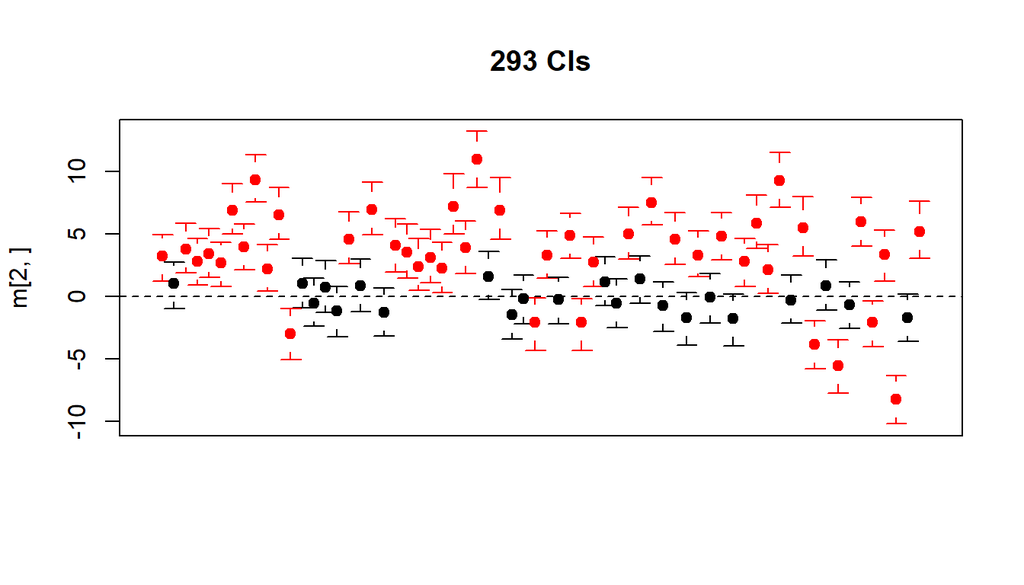

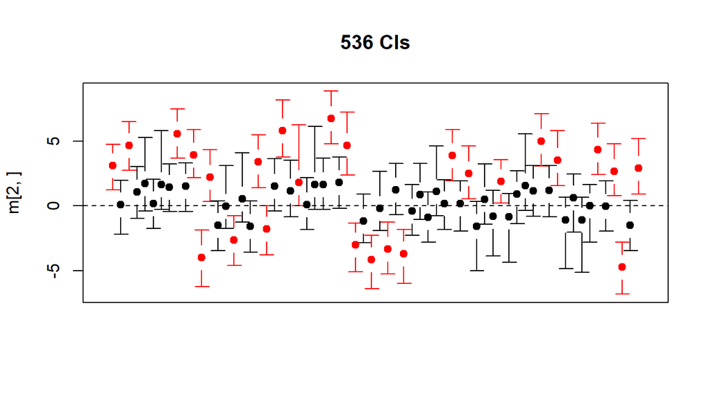

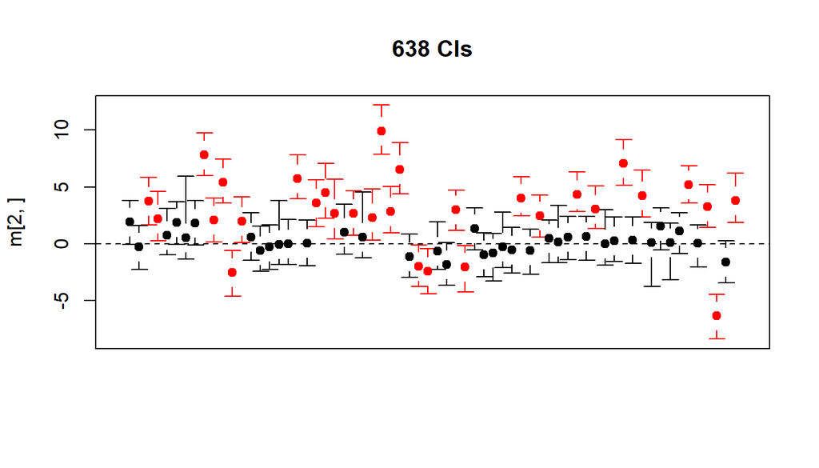

```r
boot.per = lapply(X = dfs, function(df) {
    apply(X = pairs, MARGIN = 2, FUN = bootstrap.ci, df = df, pay = "PctPatientPays")
})
boot.per.cor = lapply(X = dfs, function(df) {
    apply(X = pairs, MARGIN = 2, FUN = bootstrap.ci, df = df, pay = "PctPatientPays",
        correct = T)
})

plot.ci(boot.per)
```

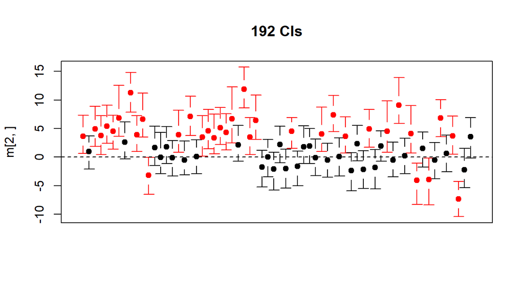

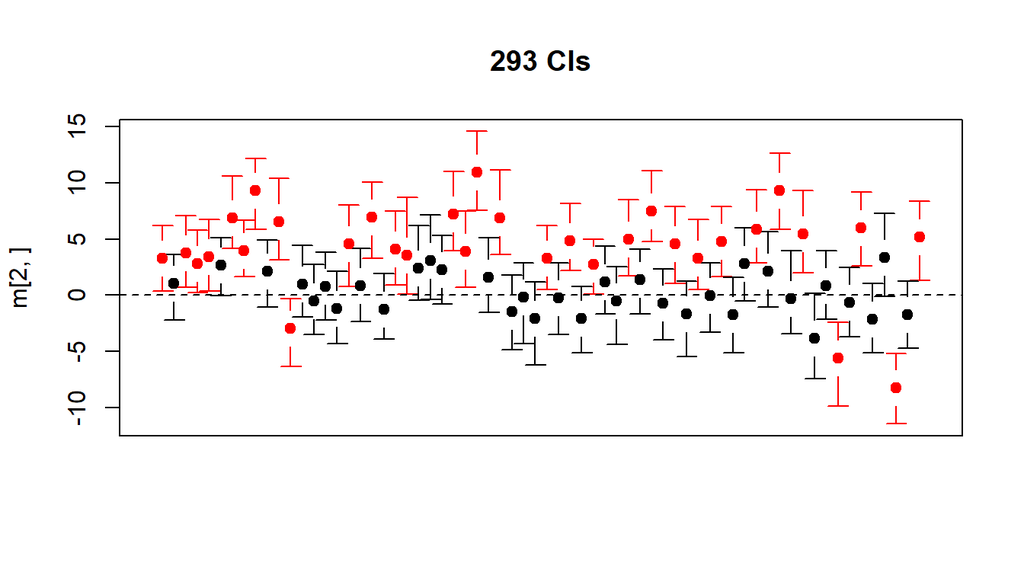

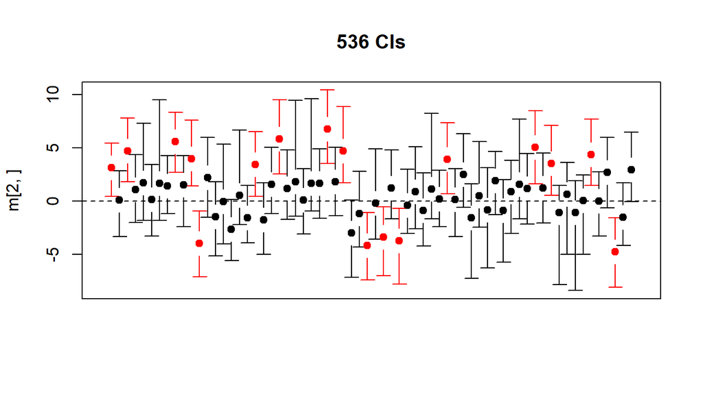

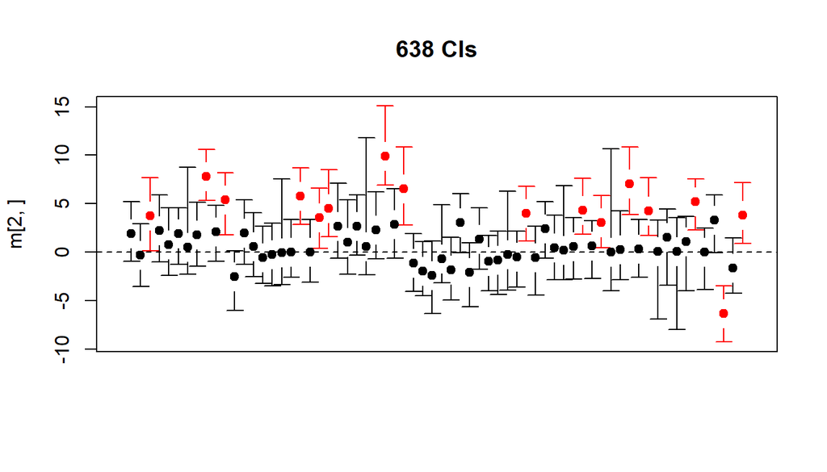

```r
plot.ci(boot.per.cor)
```

## 5 : Comment on the overall analysis

Overall, I think that my analysis was alright with the terms that I still don’t know many of the consequences of choosing the tests that I had chosen to do in the course of the project. As I did this project, there were several parts that didn’t seem right, so I made corrections to the code. At first, I made a histogram of `PatientPays` without a `log` transformation and it was missing a lot of the underlying data that was masked by the bin sizing, so I decided to use a `log` transformation so that the visualization would be cleaner and without that many bins. Also, I noticed in the violin plots (and the contingency tables) that there were several categories that had caused a clipped violin plot and this made me think about whether or not this category would be dependable in creating an accurate hypothesis test since the sample size of such observations was so small. Removing the 1, ,3, and 4 levels of `Urban` also seemed neccessary, but also it was unclear as to what removing them from the analysis would do to the overall hypothesis testing and confidence interval accuracy.  
This analysis of the difference in what a patient can pay was obviously limited in the fact that the costs of the patients were based on their health and condition (we do not know much about the patients’ health conditions or what other factors caused a lower/higher cost). The pay is also affected by the type of institute that the treatment was done in, and that affects the pay in various ways. An additional factor is that the time of stay in the institution is not recorded in the data. This can create major differences in the observations as staying longer before a patient is discharged can result in higher costs. Overall, not taking in the account of the situation of the patients creates a big limitation for the effectiveness of this analysis.  
There is also the problem of the observations for a group being too small to make an accurate analysis, such as our removal of the levels in `Urban`, and other problems discussed before.  
Since there were many limitations in this data, I would consider trying to find a different data set that includes more variables and more observations to cover regions with little data. I would also want to try doing a separate analysis of the different types of institutes and how it affects the pay.